# Математична статистика. *Лабораторна робота № 6*. Побудова моделей регресії

Ihor Polynko, KN-23-1, 2024

2024-12-05

## Постановка задачі

1. Засобами R+RStudio імпортувати файл з варіантами завдань IZ_No2.xls і для свого варіанта побудувати лінійну модель.
2. Виконати первинний аналіз лінійної моделі спочатку за допомогою графічних опцій, а потім найбільш детальний за допомогою табличних, перевірити її адекватність. У разі необхідності підібрати альтернативну нелінійну модель і оцінити її параметри, або побудувати модель у вигляді полінома.
3. Завдання оформити у вигляді динамічного електронного документа за допомогою Quarto та згенерувати електронний звіт у форматі html за заданим викладачем шаблоном. Структура звіту:

– постановка завдання;

– короткі теоретичні відомості щодо досліджуваного розподілу та методів розрахунків;

– детальна схема виконання лабораторної роботи з необхідними екранними візуалізаторами і поясненнями згідно з робочим завданням, результатами аналізу;

– висновки;

– перелік посилань, організований за допомогою bibtex.

## Розв’язок задачі

```r
# Завантаження бібліотек
library(readxl)
library(ggplot2)

# Імпорт даних з файлу
data <- read_excel("IZ_No2.xls")  # Заміни на шлях до свого файлу

# Перевірка структури даних
str(data)
```

```
## tibble [100 × 41] (S3: tbl_df/tbl/data.frame)
##  $ N : num [1:100] 1 2 3 4 5 6 7 8 9 10 ...
##  $ 2 : num [1:100] 8.17 5.74 7.89 8.38 6.35 ...
##  $ 3 : num [1:100] 9.42 8.82 5.73 6.64 5.17 5.13 5.61 7.78 5.64 7.28 ...
##  $ 4 : num [1:100] 2.45 3.56 2.67 3.74 3.19 2.56 2.24 4.29 2.09 2.6 ...
##  $ 5 : num [1:100] 1.14 1.15 -2.85 -1.17 2.1 -3.47 0.92 -2.72 0.63 0.8 ...
##  $ 6 : num [1:100] 9.03 5.98 6.43 8.57 6.95 8.97 9.13 9.39 5.73 9.84 ...
##  $ 7 : num [1:100] 5.06 5.67 3.04 3.28 3.25 3.56 5.44 3.39 3.21 5.02 ...
##  $ 8 : num [1:100] -0.42 -3.79 2.16 5.79 5.62 6.5 -4.83 -0.11 5.36 -3.34 ...
##  $ 9 : num [1:100] 0.94 -3.37 -0.98 2.26 0.03 3.13 2.92 -3.76 3.39 0.1 ...
##  $ 10: num [1:100] 16.23 13.49 15.08 4.47 13.98 ...
##  $ 11: num [1:100] 1.07 1.22 1.41 7.73 10.01 ...
##  $ 12: num [1:100] 3.81 4.39 0.74 1.42 0.85 0.89 0.37 0.26 0.08 0.64 ...
##  $ 13: num [1:100] 4.31 3.07 0.43 7.75 0.06 0.41 0.55 0.59 3.78 0.21 ...
##  $ 14: num [1:100] -5.02 -5.34 -4.9 -3.8 -5.17 -6.1 -2.39 -3.96 -5.39 -4.68 ...
```

[output cut: 27 more lines]

```r
# Вибір необхідних стовпців для X та Y за індексацією
X <- data[[6]]  # Колонка 6 для X
Y <- data[[31]]  # Колонка 31 для Y

# Перевірка, чи коректно вибрано X та Y
head(X)
```

```
## [1] 9.03 5.98 6.43 8.57 6.95 8.97
```

```r
head(Y)
```

```
## [1] 11748.162  2966.505  3695.106  8890.493  4704.766 11536.521
```

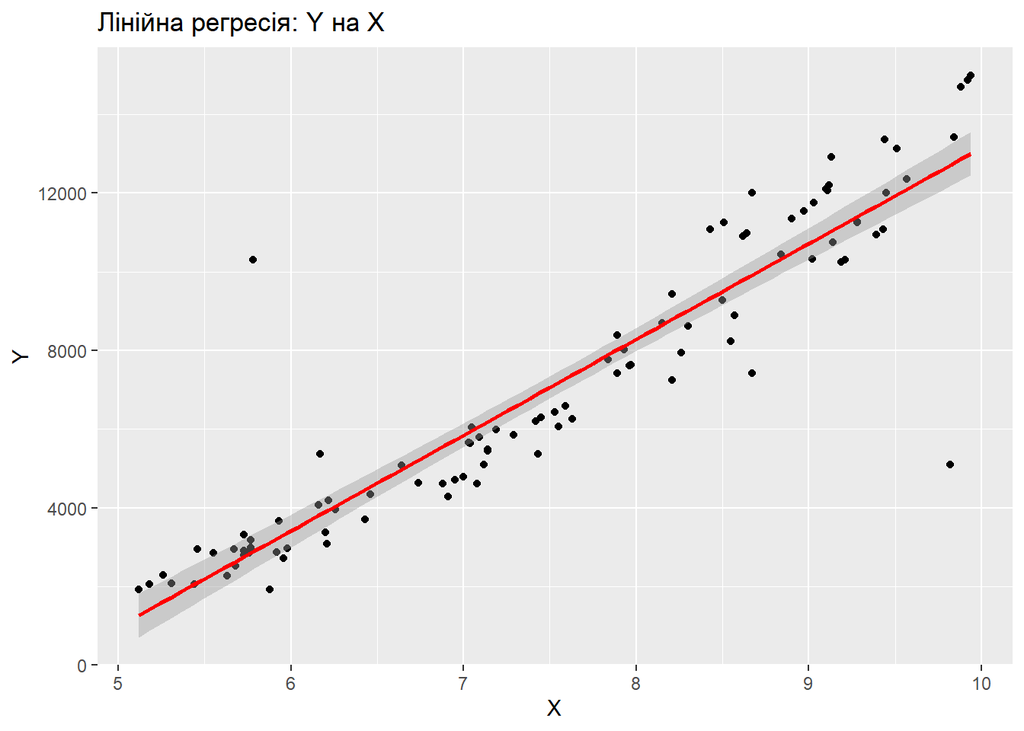

```r
# Побудова лінійної моделі
model <- lm(Y ~ X)

# 3. Первинний графічний аналіз
# Графік залишків
ggplot(data, aes(x = X, y = Y)) +
  geom_point() +
  geom_smooth(method = "lm", col = "red") +
  labs(title = "Лінійна регресія: Y на X",
       x = "X",
       y = "Y")
```

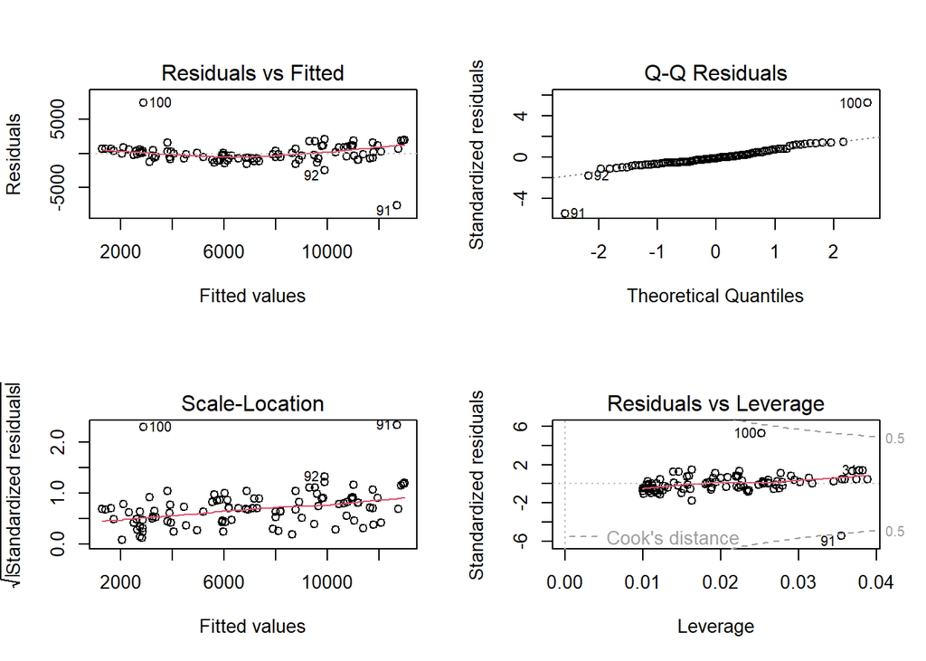

```r
# Аналіз залишків
par(mfrow = c(2, 2))
plot(model)
```